# Loan Grade and Interest Rate Prediction of Housing-Related Loans from the Lending Club Dataset

SVM Accuracy Rate: 0.71 (when validated on sample of test data)

```r
# predict grade by classification using support-vector machines (SVM) (2)
acc <- array(dim=500)
names(houseTrain)
```

```
##  [1] "grade"          "home_ownership" "annual_inc"     "total_acc"
##  [5] "default"        "revol_util"     "dti"            "loc"
##  [9] "circulated"     "loan_mth"
```

```r
for(i in 1:500) {
  svm.loans <- svm(grade~.-annual_inc-total_acc-circulated,data=houseTrain,kernel="radial",scale=T,cost=i)
  svm.predict <- predict(svm.loans,newdata=houseTest,decision.values=T)
  acc[i] = round(mean(svm.predict == houseTest$grade),5)
}
cost <- which(acc == max(acc))[[1]]
svm.loans <- svm(grade~.-annual_inc-total_acc-circulated,data=houseTrain,kernel="radial",scale=T,cost=cost)
svm.predict <- predict(svm.loans,newdata=houseTest,decision.values=T)
```

The below code implements a LASSO regression analysis to predict the interest_rates on housing and mortgage-related loans. The choice to implement a LASSO regression was one of both convenience and practicality. With as many variables as were present in the original dataset, the LASSO’s ability to force both the shrinkage and effective elimination of less significant predictors on the target was attractive. Additionally, a well-trained LASSO is a more robust statistical tool (because of its shrinkage penalties) than ordinary Least-Squares and so I felt it would be a more apt regression tool to use to approximate the interest rates of value in my analysis.

RMSE/Range = ~6.30%

```r
# predict interest rate using LASSO (1)
houseTrain$int_rate <- housePred[inTrain[1:1500],"int_rate"]
houseTest <- (within(housePred,rm("id"))[-inTrain,])[1:500,]
lasso.bind <- rbind(houseTrain,houseTest)
lasso_matrix <- model.matrix(int_rate~.-loc-total_acc,data=lasso.bind)
house.lasso <- glmnet(lasso_matrix[1:1500,],lasso.bind[1:1500,"int_rate"])
```

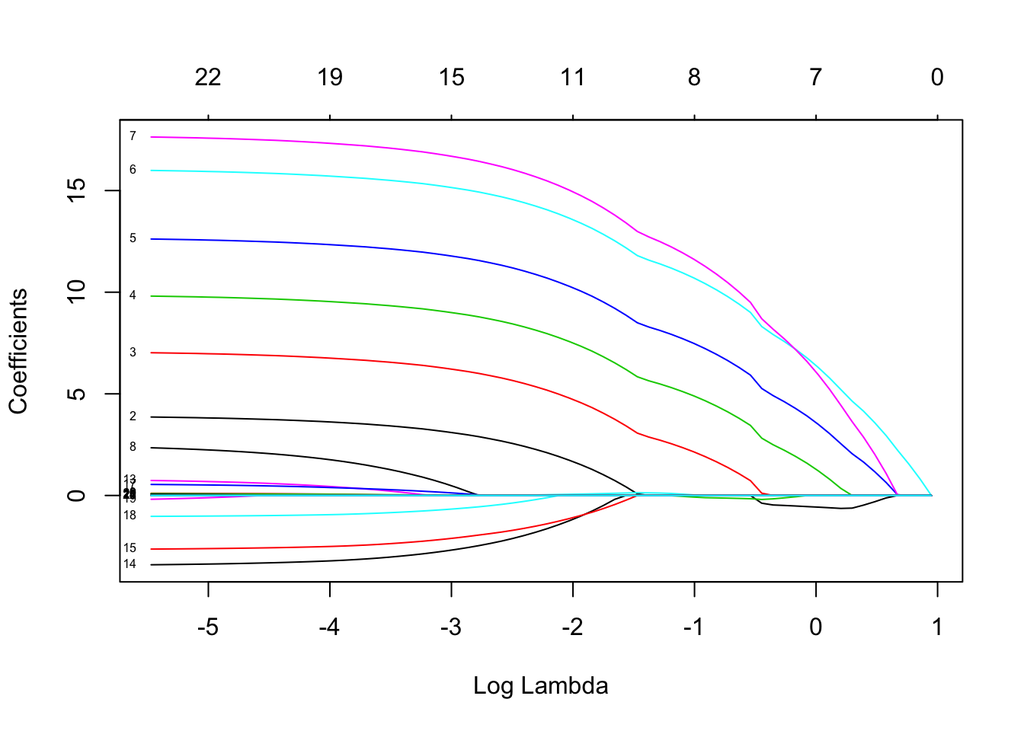

```r
lasso.predDF <- model.matrix(int_rate~.-loc-total_acc,data=lasso.bind[1501:2000,])
lasso.pred <- predict(house.lasso,lasso.predDF)
y <- lasso.bind[1501:2000,"int_rate"]
rmse.lasso <- sqrt(apply((y-lasso.pred)^2,2,mean))
lam.best <- house.lasso$lambda[order(rmse.lasso)[1]]
index <- which(house.lasso$lambda == lam.best)
lasso.coef <- coef(house.lasso,s=lam.best) # extract coefficients
```

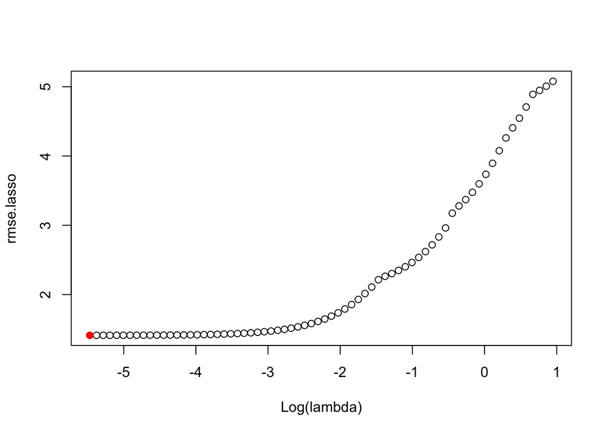

```r
best_pred <- lasso.pred[,index] # best predictions
range <- range(y)[[2]]-range(y)[[1]]
```